# 13 - Generalized Additive Models

Francisco E. Fonturbel

2/November/2022

# Non-linear models

Generalized Linear Models relax some assumptions but assume that predictor variables have a **linear** relationship with the response variable. But what if our response variable is not linear? Fortunately, we have a non-linear approach called Generalized Additive Models, in which we can use linear and non-linear predictors in the same model.

To illustrate this lesson, we will use country-scale data from the United Nations report in education and human development.

```r
library(mgcv)
library(ggplot2)
library(ggeffects)
library(gratia)
source("multiplot.R")

data<-read.csv("data/13_UN_data.csv",
                     header=TRUE,
                     sep=",",
                     dec=".",
                     na.strings="NA")
attach(data)

##Some ggplot2 grooming
My_Theme = theme(
  axis.title.x = element_text(size = 20,face="bold"),
  axis.text.x = element_text(size = 16),
  axis.text.y = element_text(size = 16),
  axis.title.y = element_text(size = 20,face="bold"),
  legend.text = element_text(size = 14),
  legend.title = element_text(size = 14,face="bold"),
  panel.grid.major = element_blank(),
  panel.grid.minor = element_blank(),
  panel.background = element_rect(fill = "white"))
```

How our variables look like? Let’s use `ggplot` to make some awesome plots:

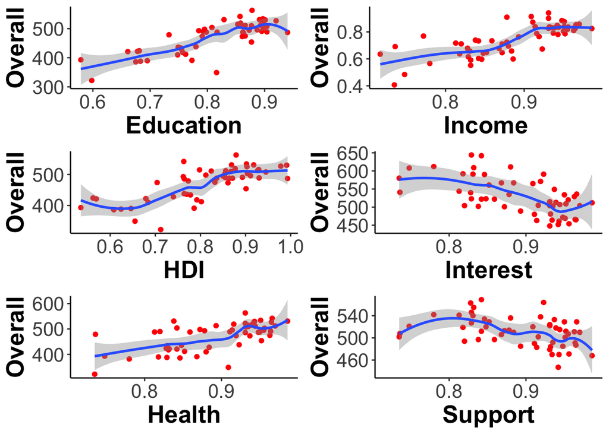

```r
a1<-ggplot(data=data, aes(x=HDI, y=Overall)) +
  geom_point(color="red") +
  geom_smooth(size=1, span = 0.5, method = "loess") + labs(x="Education", y="Overall") +
  theme_classic() +
  My_Theme
a2<-ggplot(data=data, aes(x=Edu, y=Overall)) +
  geom_point(color="red") +
  geom_smooth(size=1, span = 0.5, method = "loess") + labs(x="HDI", y="Overall") +
  theme_classic() +
  My_Theme
a3<-ggplot(data=data, aes(x=Health, y=Overall)) +
  geom_point(color="red") +
  geom_smooth(size=1, span = 0.5, method = "loess") + labs(x="Health", y="Overall") +
  theme_classic() +
  My_Theme
a4<-ggplot(data=data, aes(x=Health, y=Income)) +
  geom_point(color="red") +
  geom_smooth(size=1, span = 0.5, method = "loess") + labs(x="Income", y="Overall") +
  theme_classic() +
  My_Theme
a5<-ggplot(data=data, aes(x=Health, y=Interest)) +
  geom_point(color="red") +
  geom_smooth(size=1, span = 0.5, method = "loess") + labs(x="Interest", y="Overall") +
  theme_classic() +
  My_Theme
a6<-ggplot(data=data, aes(x=Health, y=Support)) +
  geom_point(color="red") +
  geom_smooth(size=1, span = 0.5, method = "loess") + labs(x="Support", y="Overall") +
  theme_classic() +
  My_Theme
multiplot(a1, a2, a3, a4, a5, a6, cols = 2)
```

As we can see, those predictor variables are not quite linear…

## Comparing GLM vs GAM performance

Linear model:

```r
mod_lm = gam(Overall ~ Income, data = data)
summary(mod_lm)
```

```
##
## Family: gaussian
## Link function: identity
##
## Formula:
## Overall ~ Income
##
## Parametric coefficients:
##             Estimate Std. Error t value Pr(>|t|)
## (Intercept)   204.32      35.37   5.777 4.32e-07 ***
## Income        355.85      46.79   7.606 5.36e-10 ***
## ---
## Signif. codes:  0 '***' 0.001 '**' 0.01 '*' 0.05 '.' 0.1 ' ' 1
##
##
## R-sq.(adj) =  0.518   Deviance explained = 52.7%
## GCV = 1504.5  Scale est. = 1448.8    n = 54
```

Non-linear model:

```r
mod_gam1 = gam(Overall ~ s(Income, bs = "cr"), data = data)
summary(mod_gam1)
```

```
##
## Family: gaussian
## Link function: identity
##
## Formula:
## Overall ~ s(Income, bs = "cr")
##
## Parametric coefficients:
##             Estimate Std. Error t value Pr(>|t|)
## (Intercept)  470.444      4.082   115.3   <2e-16 ***
## ---
## Signif. codes:  0 '***' 0.001 '**' 0.01 '*' 0.05 '.' 0.1 ' ' 1
##
## Approximate significance of smooth terms:
##             edf Ref.df     F p-value
## s(Income) 6.895  7.741 16.67  <2e-16 ***
## ---
## Signif. codes:  0 '***' 0.001 '**' 0.01 '*' 0.05 '.' 0.1 ' ' 1
##
## R-sq.(adj) =    0.7   Deviance explained = 73.9%
## GCV = 1053.7  Scale est. = 899.67    n = 54
```

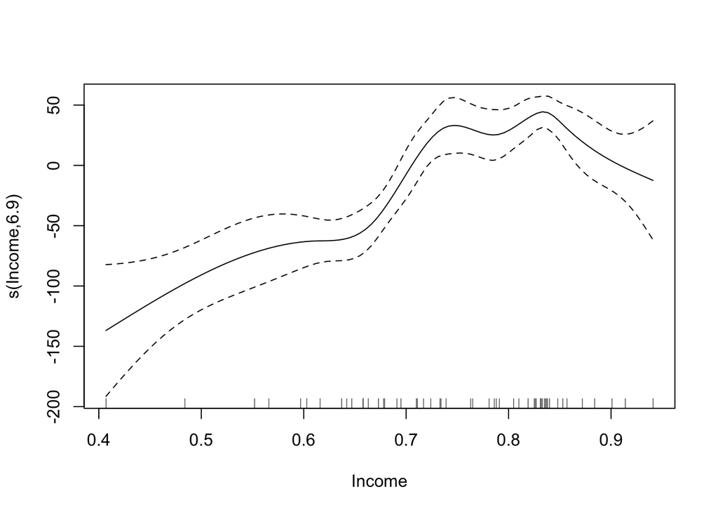

```r
plot(mod_gam1)
```

**Linear model performance:**

```r
AIC(mod_lm)
```

```
## [1] 550.2449
```

```r
summary(mod_lm)$r.sq
```

```
## [1] 0.5175346
```

**Non-linear model performance:**

```r
AIC(mod_gam1)
```

```
## [1] 529.8093
```

```r
summary(mod_gam1)$r.sq
```

```
## [1] 0.7003963
```

As we can see, the GAM model has a better performance than the GLM model. Let’s make a formal test using `anova`:

```r
anova(mod_lm, mod_gam1, test = "Chisq")
```

```
## Analysis of Deviance Table
##
## Model 1: Overall ~ Income
## Model 2: Overall ~ s(Income, bs = "cr")
##   Resid. Df Resid. Dev     Df Deviance  Pr(>Chi)
## 1    52.000      75336
## 2    45.259      41479 6.7411    33857 2.778e-06 ***
## ---
## Signif. codes:  0 '***' 0.001 '**' 0.01 '*' 0.05 '.' 0.1 ' ' 1
```

Well, the GAM model is significantly better than the GLM model.

## Using multiple predictors

As in GLM, we can fit multiple predictors in GAM, let’s see an example:

```r
mod_gam2 = gam(Overall ~ s(Income) + s(Edu) + s(Health) + Health, data = data)
summary(mod_gam2)
```

```
##
## Family: gaussian
## Link function: identity
##
## Formula:
## Overall ~ s(Income) + s(Edu) + s(Health) + Health
##
## Parametric coefficients:
##             Estimate Std. Error t value Pr(>|t|)
## (Intercept)  263.090      1.561   168.5   <2e-16 ***
## Health       233.140      1.396   167.0   <2e-16 ***
## ---
## Signif. codes:  0 '***' 0.001 '**' 0.01 '*' 0.05 '.' 0.1 ' ' 1
##
## Approximate significance of smooth terms:
##              edf Ref.df      F  p-value
## s(Income) 7.5929 8.4148  8.826 1.29e-06 ***
## s(Edu)    6.2043 7.1776  3.308 0.007714 **
## s(Health) 0.9978 0.9978 13.696 0.000723 ***
## ---
## Signif. codes:  0 '***' 0.001 '**' 0.01 '*' 0.05 '.' 0.1 ' ' 1
##
## Rank: 28/29
## R-sq.(adj) =  0.863   Deviance explained = 90.3%
## GCV = 573.83  Scale est. = 399.5     n = 52
```

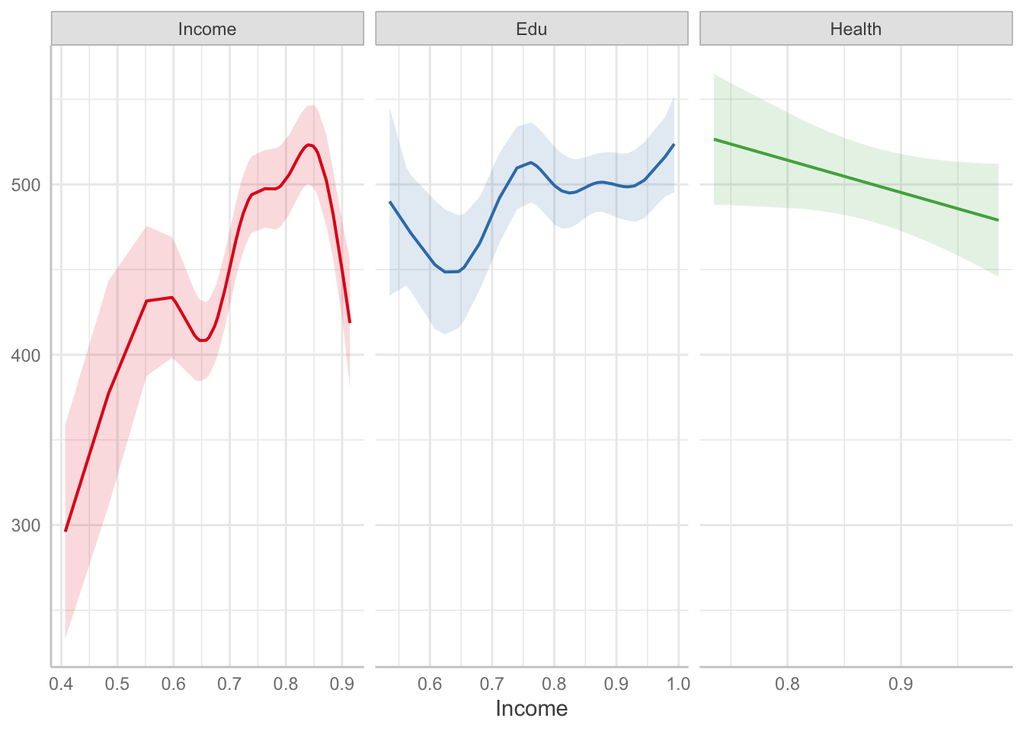

```r
plot(ggeffects::ggpredict(mod_gam2), facets = TRUE)
```

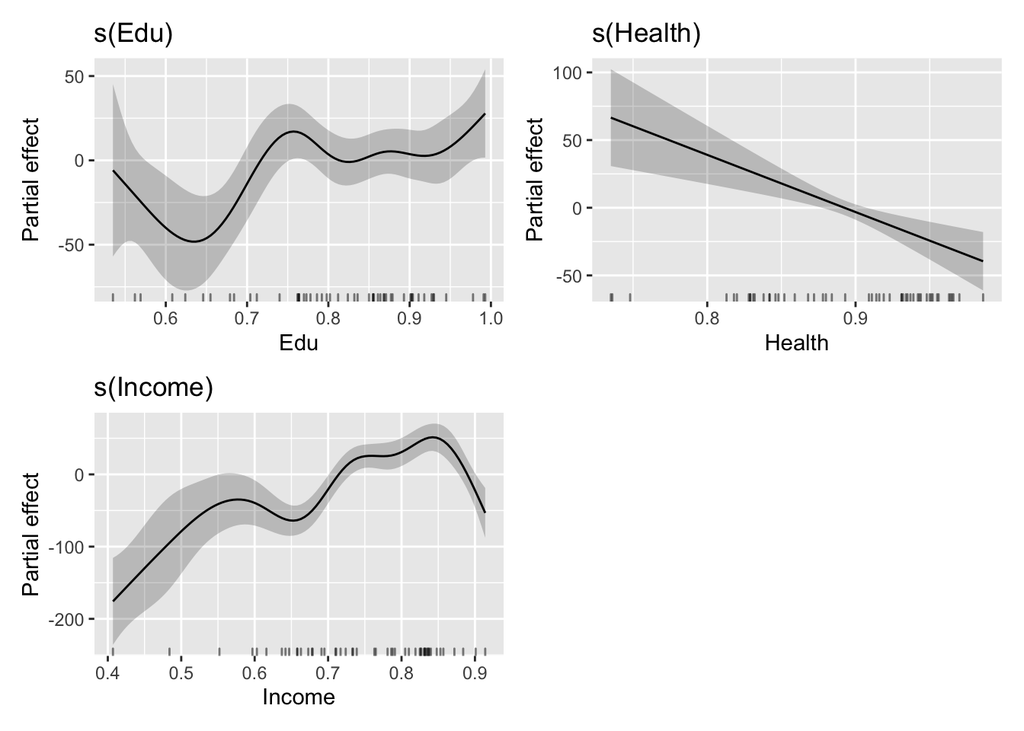

```r
gratia::draw(mod_gam2)
```

### An alternative visualization

Now we will use a 2D smooth to visualize our model:

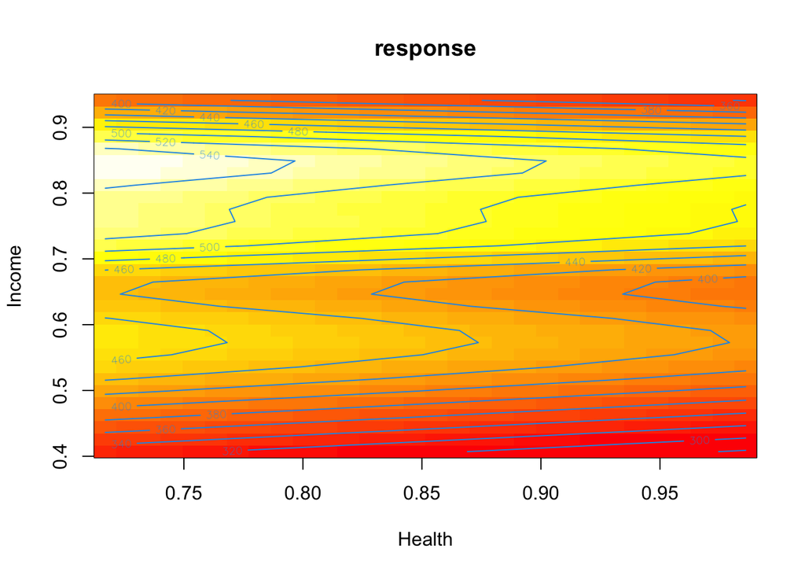

```r
vis.gam(mod_gam2, type = 'response', plot.type = 'contour')
```

## Final thoughts

GAM model allow us to include non-linear predictors using a *spline* function. We can mix linear and non-linear predictors within the same model. Including non-linear terms as splines significantly improve the fit of the model, leading to more reliable results.

Licensing Creative Commons License

Licensed under a Creative Commons Attribution-ShareAlike 4.0 International License.  
2022 - Francisco E. Fontúrbel